# Week_6_Problem_Set

Dan Crownover

2023-02-22

Data: House sparrows were found on the ground after a severe winter storm in 1898, some of which survived and others of which perished. We are going to analyze the explanatory variables that determine whether a sparrow survived or not.

Variables include: bird weight, WT age, AG total length, TL alar extent, AE length of beak and head, BH, length of humerus, HL, length of femur, FL, length of tibio-tarsus, TT, width of skull, SK, length of keel of sternum, KL.

Question 1:

1.1 Fit a simple logistic regression model with just bird weight as the x variable and survival as the y variable.

1.2 Make a boxplot comparing survival across different weights (2.5)

We fitted a logistic model (estimated using ML) to predict Status with WT (formula: Status ~ WT). The model’s explanatory power is weak (Tjur’s R2 = 0.07). The model’s intercept, corresponding to WT = 0, is at 11.32 (95% CI [2.94, 20.76], p = 0.012). Within this model:

- The effect of WT is statistically significant and negative (beta = -0.42, 95% CI [-0.79, -0.10], p = 0.015; Std. beta = -0.60, 95% CI [-1.12, -0.14])

1.5. Report and discuss the results from the likelihood ratio test (5) The LR chi-square test indicates a significant association between the predictor variable WT and the outcome variable, with a chi-square value of 6.7595 and 1 degree of freedom (DF), yielding a p-value of 0.009325, denoted by **. We reject the model with null that both of the models have the same liklihood (which model fits better) that data are equal, so now we can assume that the model using weight are better than other.

1.6 Check the assumptions of the model (5) The Maximum Likelihood Estimation (MLE) of lambda is 4.6009. The Score Statistic (t) is -0.3006 with a corresponding p-value of 0.7644, indicating no significant deviation from the null hypothesis. the standard residuals where 87 and false. all of these passed the assumptions and we can continue with q 2

2.2 Check the assumptions of linearity. Decide whether or not to include or exclude predictor variables based on linearity. (2.5) See question 2.2

- Plot the ROC of your model (from the 70%, 30% split) and report out the AUC on the plot. (5)

#### 1.2 Load and examine data

[1] “Perished” “Survived”

#### 1.2 Box Plot of Data Sets

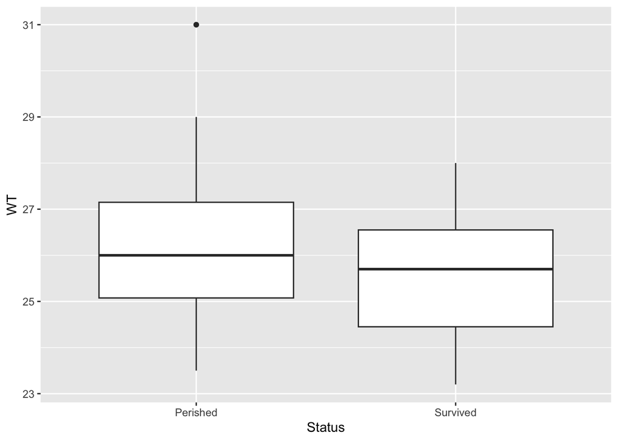

Call: glm(formula = Status ~ WT, family = binomial(link = logit), data = sdat)

Coefficients: Estimate Std. Error z value Pr(>|z|)  
(Intercept) 11.3201 4.5053 2.513 0.0120 *WT -0.4244 0.1738 -2.441 0.0146* — Signif. codes: 0 ‘**’ 0.001 ’**’ 0.01 ’’ 0.05 ‘.’ 0.1 ’ ’ 1

(Dispersion parameter for binomial family taken to be 1)

```
Null deviance: 118.01  on 86  degrees of freedom
```

Residual deviance: 111.25 on 85 degrees of freedom AIC: 115.25

Number of Fisher Scoring iterations: 4

#### 1.3 Example Coeficients

(Intercept) WT 8.246416e+04 6.541611e-01

#### 1.4 Wald Confidence Interval

Call: glm(formula = Status ~ WT, family = binomial(link = logit), data = sdat)

Coefficients: Estimate Std. Error z value Pr(>|z|)  
(Intercept) 11.3201 4.5053 2.513 0.0120 *WT -0.4244 0.1738 -2.441 0.0146* — Signif. codes: 0 ‘**’ 0.001 ’**’ 0.01 ’’ 0.05 ‘.’ 0.1 ’ ’ 1

(Dispersion parameter for binomial family taken to be 1)

```
Null deviance: 118.01  on 86  degrees of freedom
```

Residual deviance: 111.25 on 85 degrees of freedom AIC: 115.25

Number of Fisher Scoring iterations: 4

We fitted a logistic model (estimated using ML) to predict Status with WT (formula: Status ~ WT). The model’s explanatory power is weak (Tjur’s R2 = 0.07). The model’s intercept, corresponding to WT = 0, is at 11.32 (95% CI [2.94, 20.76], p = 0.012). Within this model:

- The effect of WT is statistically significant and negative (beta = -0.42, 95% CI [-0.79, -0.10], p = 0.015; Std. beta = -0.60, 95% CI [-1.12, -0.14])

#### 1.5 Anova

Analysis of Deviance Table (Type II tests)

Response: Status LR Chisq Df Pr(>Chisq)  
WT 6.7595 1 0.009325 ** — Signif. codes: 0 ‘**’ 0.001 ’**’ 0.01 ’’ 0.05 ‘.’ 0.1 ’ ’ 1

#### 1.6 Plot residuals

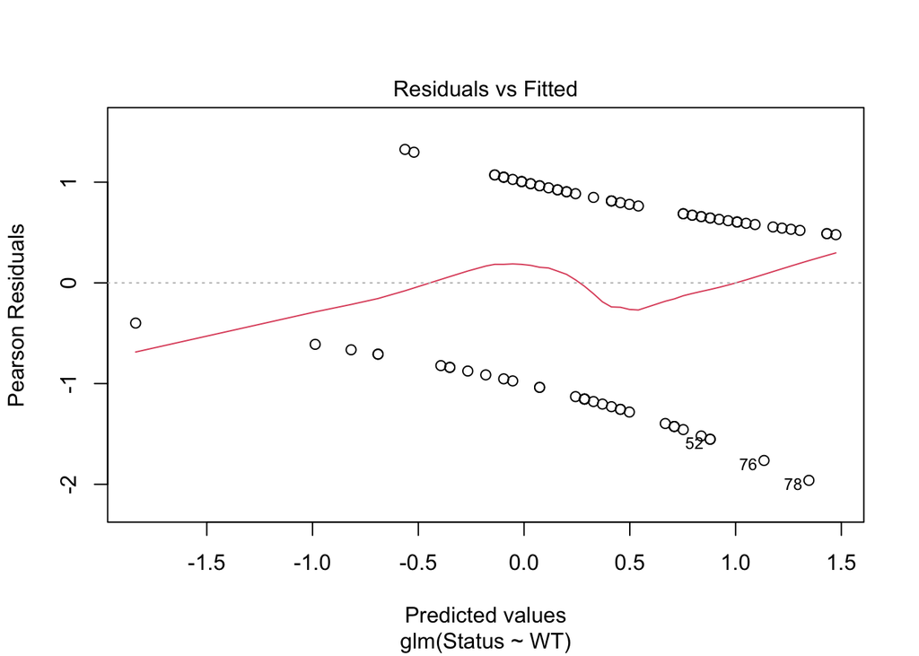

#### 1.6 Tildwell Test

MLE of lambda Score Statistic (t) Pr(>|t|) 4.6009 -0.3006 0.7644

iterations = 5

#### 1.6 Standard Residuals

FALSE 87

#### Question 2

#### 2.1 Converting Status a Factor

bird weight, WT age, AG total length, TL alar extent, AE length of beak and head, BH, length of humerus, HL, length of femur, FL, length of tibio-tarsus, TT, width of skull, SK, length of keel of sternum, KL.

#### 2.1 Developing Model

Summary of mod2 glm Model

|  | Estimate | Std. Error | z value | Pr(>&#124;z&#124;) |
| --- | --- | --- | --- | --- |
| (Intercept) | 27.4597535 | 26.4398334 | 1.0385751 | 0.2990024 |
| WT | -0.8886020 | 0.3418218 | -2.5996059 | 0.0093331 |
| AG | 0.1063088 | 0.6825332 | 0.1557562 | 0.8762252 |
| TL | -0.7363429 | 0.1896508 | -3.8826252 | 0.0001033 |
| AE | 0.0827541 | 0.1262201 | 0.6556338 | 0.5120598 |
| BH | 0.5829339 | 0.5973510 | 0.9758649 | 0.3291314 |
| HL | 56.0349419 | 31.0554084 | 1.8043537 | 0.0711759 |
| FL | -6.6468001 | 31.7344171 | -0.2094508 | 0.8340963 |
| TT | 5.0521288 | 14.0526283 | 0.3595149 | 0.7192100 |
| SK | 21.5312115 | 27.2848181 | 0.7891279 | 0.4300372 |
| KL | 23.5611070 | 12.0382596 | 1.9571855 | 0.0503257 |

Call: glm(formula = Status ~ WT + AG + TL + AE + BH + HL + FL + TT + SK + KL, family = binomial(link = logit), data = sdat)

Coefficients: Estimate Std. Error z value Pr(>|z|)  
(Intercept) 27.45975 26.43983 1.039 0.299002  
WT -0.88860 0.34182 -2.600 0.009333 ** AG 0.10631 0.68253 0.156 0.876225  
TL -0.73634 0.18965 -3.883 0.000103 *** AE 0.08275 0.12622 0.656 0.512060  
BH 0.58293 0.59735 0.976 0.329131  
HL 56.03494 31.05541 1.804 0.071176 .  
FL -6.64680 31.73442 -0.209 0.834096  
TT 5.05213 14.05263 0.360 0.719210  
SK 21.53121 27.28482 0.789 0.430037  
KL 23.56111 12.03826 1.957 0.050326 .  
— Signif. codes: 0 ‘**’ 0.001 ’**’ 0.01 ’’ 0.05 ‘.’ 0.1 ’ ’ 1

(Dispersion parameter for binomial family taken to be 1)

```
Null deviance: 118.01  on 86  degrees of freedom
```

Residual deviance: 65.92 on 76 degrees of freedom AIC: 87.92

Number of Fisher Scoring iterations: 6 ## 2.1 VIF model

|  | x |
| --- | --- |
| WT | 2.221337 |
| AG | 1.070817 |
| TL | 2.714908 |
| AE | 3.274337 |
| BH | 1.892614 |
| HL | 4.971644 |
| FL | 6.064703 |
| TT | 4.024184 |
| SK | 1.280141 |
| KL | 1.889075 |

#### 2.2 Linearity

Call: glm(formula = Status ~ WT + AG + TL + AE + BH + HL + FL + TT + SK + KL, family = binomial(link = logit), data = sdat)

Coefficients: Estimate Std. Error z value Pr(>|z|)  
(Intercept) 27.45975 26.43983 1.039 0.299002  
WT -0.88860 0.34182 -2.600 0.009333 ** AG 0.10631 0.68253 0.156 0.876225  
TL -0.73634 0.18965 -3.883 0.000103 *** AE 0.08275 0.12622 0.656 0.512060  
BH 0.58293 0.59735 0.976 0.329131  
HL 56.03494 31.05541 1.804 0.071176 .  
FL -6.64680 31.73442 -0.209 0.834096  
TT 5.05213 14.05263 0.360 0.719210  
SK 21.53121 27.28482 0.789 0.430037  
KL 23.56111 12.03826 1.957 0.050326 .  
— Signif. codes: 0 ‘**’ 0.001 ’**’ 0.01 ’’ 0.05 ‘.’ 0.1 ’ ’ 1

(Dispersion parameter for binomial family taken to be 1)

```
Null deviance: 118.01  on 86  degrees of freedom
```

Residual deviance: 65.92 on 76 degrees of freedom AIC: 87.92

Number of Fisher Scoring iterations: 6

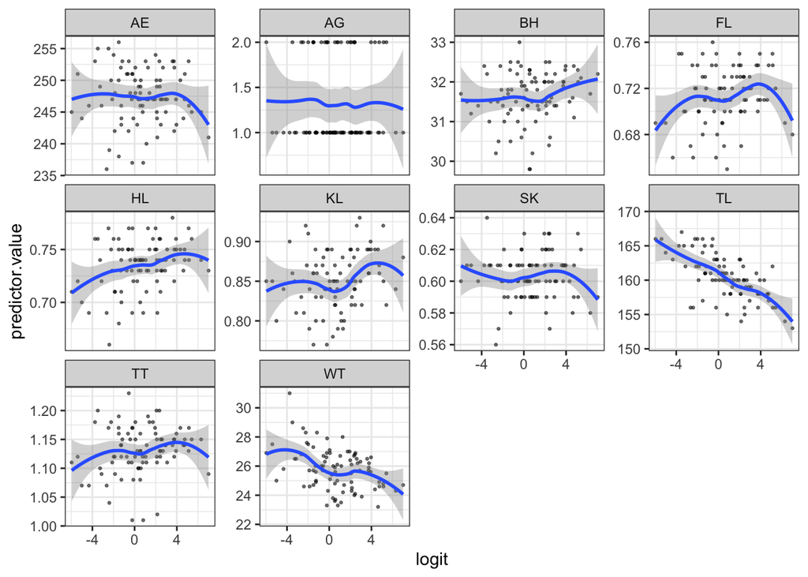

#### 2.2 Box Tidwell: are linear assumptions met

MLE of lambda Score Statistic (t) Pr(>|t|) 38.424 -0.1906 0.8493

iterations = 26 MLE of lambda Score Statistic (t) Pr(>|t|) 14.754 -0.7665 0.4455

iterations = 3 MLE of lambda Score Statistic (t) Pr(>|t|) 4.6009 -0.3006 0.7644

iterations = 5 MLE of lambda Score Statistic (t) Pr(>|t|) 31.118 1.049 0.2972

iterations = 26 MLE of lambda Score Statistic (t) Pr(>|t|) 23.037 0.9512 0.3442

iterations = 26 MLE of lambda Score Statistic (t) Pr(>|t|) -184.55 -0.1557 0.8766

iterations = 26 MLE of lambda Score Statistic (t) Pr(>|t|) -9.8942 -0.2317 0.8173

iterations = 9 MLE of lambda Score Statistic (t) Pr(>|t|) 202.7 0.9464 0.3467

iterations = 16 #### 2.2 Removing Values

Call: glm(formula = Status ~ WT + AG + TL + AE + BH + HL + SK, family = binomial(link = “logit”), data = sdat)

Coefficients: Estimate Std. Error z value Pr(>|z|)  
(Intercept) 15.84327 23.61227 0.671 0.502236  
WT -0.74205 0.31816 -2.332 0.019684 *  
AG 0.06211 0.66079 0.094 0.925115  
TL -0.68255 0.17592 -3.880 0.000104 ** AE 0.13274 0.12055 1.101 0.270840  
BH 0.81745 0.55315 1.478 0.139454  
HL 54.13676 23.51350 2.302 0.021314  
SK 24.47716 25.58994 0.957 0.338812  
— Signif. codes: 0 ‘**’ 0.001 ’**’ 0.01 ’’ 0.05 ‘.’ 0.1 ’ ’ 1

(Dispersion parameter for binomial family taken to be 1)

```
Null deviance: 118.008  on 86  degrees of freedom
```

Residual deviance: 70.408 on 79 degrees of freedom AIC: 86.408

Number of Fisher Scoring iterations: 5

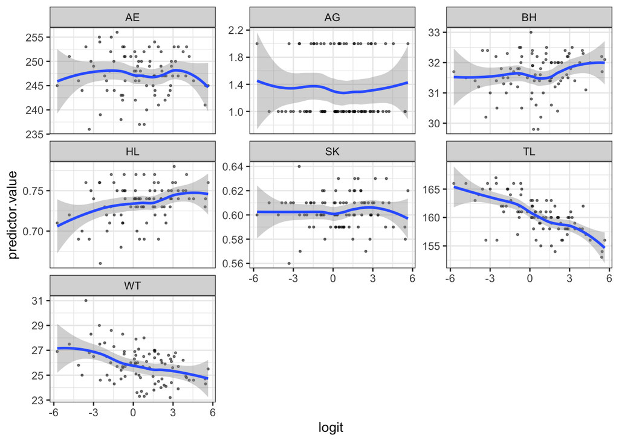

#### 2.3 Cross Validation:

```
     R2      RMSE       MAE
```

1 0.2324016 0.4460349 0.3872052

Model Evaluation Metrics

| R2 | RMSE | MAE |
| --- | --- | --- |
| 0.2324016 | 0.4460349 | 0.3872052 |

#### 2.4

#### 2.3 Interpreting the coeficcients of the Best model question 2.3 part 2

(Intercept) WT TL AE HL 4.368073e+02 9.155759e-01 9.172817e-01 1.015521e+00 1.070566e+04

#### 2.4 Plot ROC curve

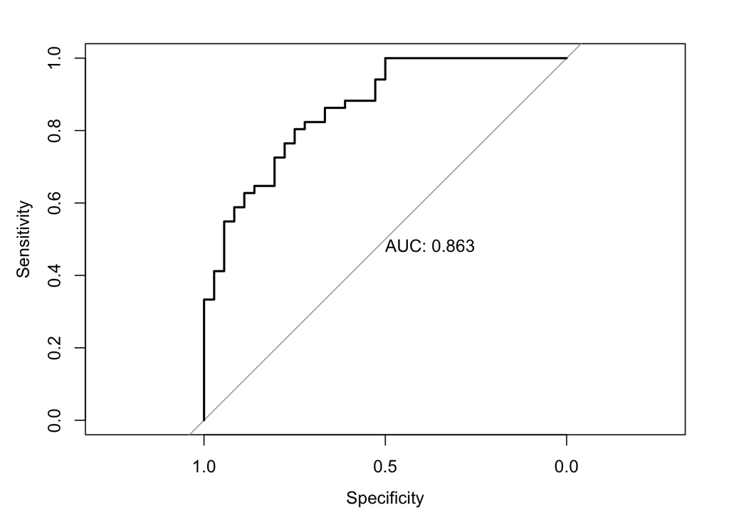

#### 2.4 Cofusion Matrix Confusion Matrix and Statistics

```
      Reference
```

Prediction 0 1 0 28 11 1 8 40

```
           Accuracy : 0.7816
             95% CI : (0.6802, 0.8631)
No Information Rate : 0.5862
P-Value [Acc > NIR] : 9.889e-05

              Kappa : 0.5553
```

Mcnemar’s Test P-Value : 0.6464

```
        Sensitivity : 0.7843
        Specificity : 0.7778
     Pos Pred Value : 0.8333
     Neg Pred Value : 0.7179
         Prevalence : 0.5862
     Detection Rate : 0.4598
```

Detection Prevalence : 0.5517  
Balanced Accuracy : 0.7810

```
   'Positive' Class : 1
```